# Kapittel 6 - disinsentiveffekter

Published

October 16, 2024

## Sykepenger - kompensasjonsgrad

#### Brutto kompensasjonsgrad i offentlige sykepengeordninger i 2015. Gjennomsnittlig ytelse de første 26 ukene i sykepengeperioden for enslig arbeidstaker med gjennomsnittlig industrilønn. Prosent av inntekt

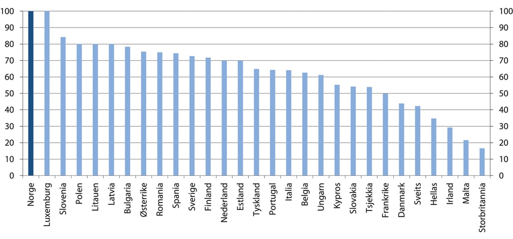

Kilde: Social Insurance Entitlements Dataset (SIED)

## 6.3.2 i Barr og ss.585-86 og 589-90 i Boeri & Ours: Problem: disinsentiveffekter

- ordninger for sykepenger og uføretrygd kritiseres for å ha tydelige disinsentiv effekter
  - skyver personer ut av arbeidsmarkedet

## Modell for sykefravær og uføretrygd

- en sykdomsindeks, $\sigma$, inkluderes i nyttefunksjonen (Barmby et al.1994).
  - høyere verdier av $\sigma$ representerer høyere nivåer av sykdom **opplevd** av individet.
- Nytten uttrykkes som en funksjon av konsum, fritid og individets nivå av sykdom eller helse:
  $$u = u(c, l, \sigma)$$
  hvor $u$ representerer individets nytte, $c$ representerer individets konsum av varer og tjenester, $l$ representerer individets fritid og $\sigma$ representerer det oppplevde sykdomsnivået for dette spesifikke individet
- En hensiktsmessig metode for framstilling oppnås ved å spesifisere Cobb-Douglas preferanser:
  $$u=c^{1-\sigma}l^\sigma$$
- Sykdomsindeksen er definert over intervallet [0,1].
  - Når $\sigma$ nærmer seg 1:
    - individet verdsetter fritid eller restitusjonstid relativt mer enn konsum
    - individet vil anvende hele sin tidsressurs på å konsumere fritid
  - Det motsatte gjelder når $\sigma$ nærmer seg null
    - Når individet opplever et lavere sykdomsnivå, tillegger han/hun relativt større vekt til konsum i forhold til fritid

## Indifferenskurver på ulike nivåer av $\sigma$

[output not shown]

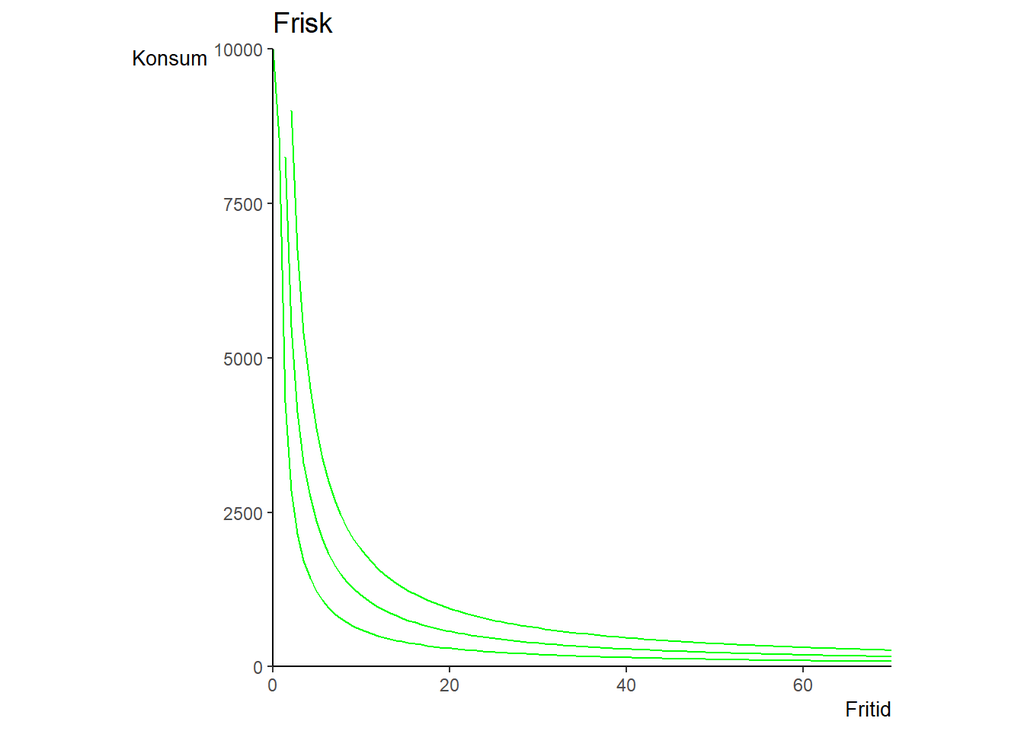

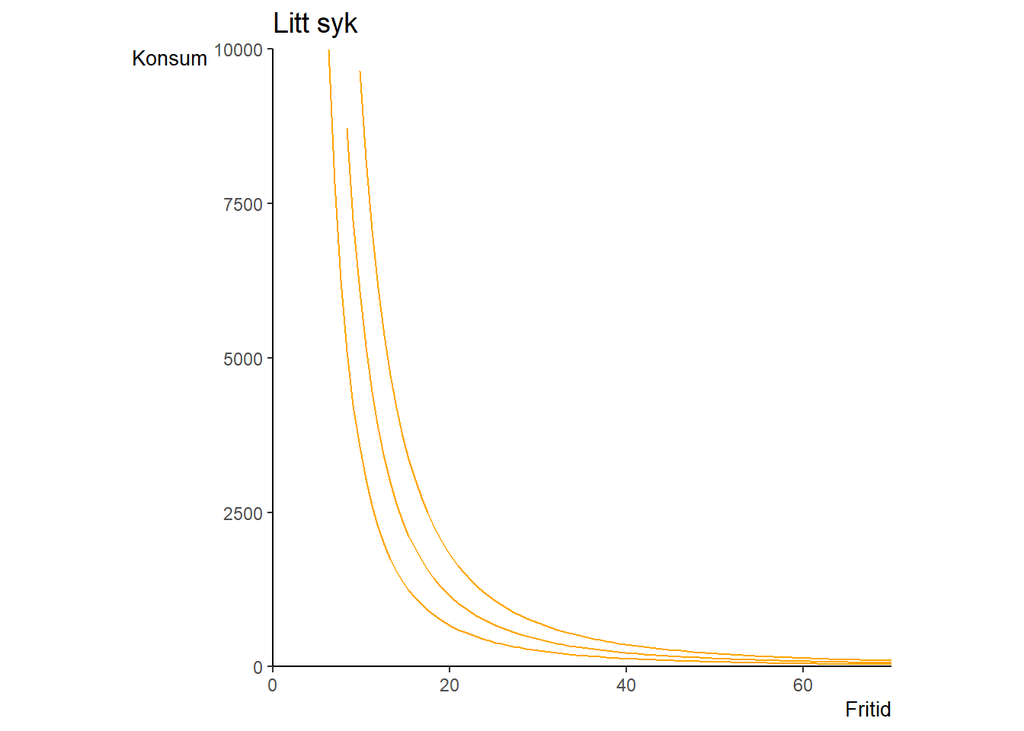

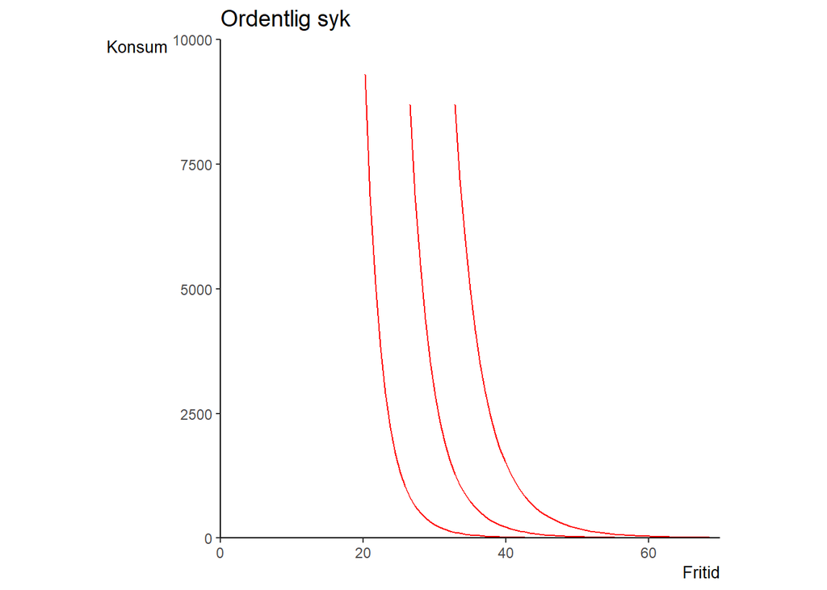

[output not shown]

```r
library(patchwork)

############ Frisk
rm(list = ls())

suppressPackageStartupMessages(library(tidyverse))

l_1 <- seq(0, 60, by = .01)


df <- data.frame(l_1)

#lag aksen for tegningen

axes_1 <- ggplot(df, aes(l_1))+
  labs(x="Fritid", y="Konsum", title = "Frisk") +
  theme(axis.title = element_text(size = 10),
        plot.title = element_text(size = 14),
        panel.background = element_blank(), # hvit bakgrunn
        axis.line = element_line(colour = "black"), # sett inn akselinjer
        axis.title.x = element_text(hjust = 1),
        axis.title.y = element_text(angle = 0, vjust = 1, hjust=1))+ # juster labels på aksene
 # coord_fixed(ratio = 1)+ # lik skala for x og y aksen
  scale_x_continuous(limits = c(0, 70), expand = c(0, 0))+
  scale_y_continuous(limits = c(0, 10000), expand = c(0, 0))+ # begrense aksene
  coord_fixed(ratio = (70 - 0) / (10000 - 0))

# og sikre at akselinjene møttes i (0,0).

# nyttefunkjsonen som brukes U=c^.5x l^.5 (Cobb-Douglas)

# vi angir noen indifferenskurver
I_1 <- function(l_1) ((77.4596669241483)/(l_1^0.5))^(1/0.5)  # nyttenivå 77.4596669241483
I_2 <- function(l_1) (((107.4596669241483)/(l_1^0.5))^(1/0.5))  # nyttenivå 77.4596669241483
I_3 <- function(l_1) (((137.4596669241483)/(l_1^0.5))^(1/0.5))  # nyttenivå 77.4596669241483


#I_1 <- function(l_1) (109.544511501033^2)/(l_1) # nytte=109.544511501033

figur_1 <- axes_1 +
     stat_function(df,
        fun=I_1,colour = "green",
        mapping = aes()
        ) +
      stat_function(df,
        fun=I_2,colour = "green",
        mapping = aes()
        ) +
      stat_function(df,
        fun=I_3,colour = "green",
        mapping = aes()
        ) + guides(colour = "none")+
  theme(legend.position = "none")
#  annotate("text",x=67,y=115, label=expression(u[0]))+
 # annotate("text",x=67,y=195, label=expression(u[1]))+
#annotate("text",x=67,y=300, label=expression(u[2]))

############ Litt syk

l_1 <- seq(0, 60, by = .01)


df <- data.frame(l_1)

#lag aksen for tegningen

axes_1 <- ggplot(df, aes(l_1))+
  labs(x="Fritid", y="Konsum", title="Litt syk") +
  theme(axis.title = element_text(size = 10),
        plot.title = element_text(size = 14),
        panel.background = element_blank(), # hvit bakgrunn
        axis.line = element_line(colour = "black"), # sett inn akselinjer
        axis.title.x = element_text(hjust = 1),
        axis.title.y = element_text(angle = 0, vjust = 1, hjust=1))+ # juster labels på aksene
 # coord_fixed(ratio = 1)+ # lik skala for x og y aksen
  scale_x_continuous(limits = c(0, 70), expand = c(0, 0))+
  scale_y_continuous(limits = c(0, 10000), expand = c(0, 0))+ # begrense aksene
  coord_fixed(ratio = (70 - 0) / (10000 - 0))
# og sikre at akselinjene møttes i (0,0).

# nyttefunkjsonen som brukes U=c^.5x l^.5 (Cobb-Douglas)

# vi angir noen indifferenskurver
I_4 <- function(l_1) ((77.4596669241483)/(l_1^0.7))^(1/0.3)  #
I_5 <- function(l_1) ((67.4596669241483)/(l_1^0.7))^(1/0.3)  #
I_6 <- function(l_1) ((57.4596669241483)/(l_1^0.7))^(1/0.3)  #



#I_1 <- function(l_1) (109.544511501033^2)/(l_1) # nytte=109.544511501033

figur_2 <- axes_1 +
     stat_function(df,
        fun=I_4,colour = "orange",
        mapping = aes()
        ) +
      stat_function(df,
        fun=I_5,colour = "orange",
        mapping = aes()
        ) +
      stat_function(df,
        fun=I_6,colour = "orange",
        mapping = aes()
        ) + guides(colour = "none")+
  theme(legend.position = "none")
 # annotate("text",x=67,y=50, label=expression(u[0]))+
#  annotate("text",x=67,y=85, label=expression(u[1]))+
#annotate("text",x=67,y=150, label=expression(u[2]))

####################
################### Syk

l_1 <- seq(0, 60, by = .01)


df <- data.frame(l_1)

#lag aksen for tegningen

axes_1 <- ggplot(df, aes(l_1))+
  labs(x="Fritid", y="Konsum", title= "Ordentlig syk") +
  theme(axis.title = element_text(size = 10),
        plot.title = element_text(size = 14),
        panel.background = element_blank(), # hvit bakgrunn
        axis.line = element_line(colour = "black"), # sett inn akselinjer
        axis.title.x = element_text(hjust = 1),
        axis.title.y = element_text(angle = 0, vjust = 1, hjust=1))+ # juster labels på aksene
 # coord_fixed(ratio = 1)+ # lik skala for x og y aksen
  scale_x_continuous(limits = c(0, 70), expand = c(0, 0))+
  scale_y_continuous(limits = c(0, 10000), expand = c(0, 0))+ # begrense aksene
  coord_fixed(ratio = (70 - 0) / (10000 - 0))
# og sikre at akselinjene møttes i (0,0).

# nyttefunkjsonen som brukes U=c^.1x l^.9 (Cobb-Douglas)

# vi angir noen indifferenskurver
I_7 <- function(l_1) ((37.4596669241483)/(l_1^0.9))^(1/0.1)  # nyttenivå 77.4596669241483
I_8 <- function(l_1) ((47.4596669241483)/(l_1^0.9))^(1/0.1)  # nyttenivå 77.4596669241483
I_9 <- function(l_1) ((57.4596669241483)/(l_1^0.9))^(1/0.1)  # nyttenivå 77.4596669241483



#I_1 <- function(l_1) (109.544511501033^2)/(l_1) # nytte=109.544511501033

figur_3 <- axes_1 +
     stat_function(df,
        fun=I_7,colour = "red",
        mapping = aes()
        ) +
      stat_function(df,
        fun=I_8,colour = "red",
        mapping = aes()
        ) +
      stat_function(df,
        fun=I_9,colour = "red",
        mapping = aes()
        ) + guides(colour = "none")+
  theme(legend.position = "none")
#  annotate("text",x=67,y=40, label=expression(u[0]))+
#  annotate("text",x=67,y=95, label=expression(u[1]))+
#annotate("text",x=67,y=350, label=expression(u[2]))


patchwork::plot_layout(figur_1, figur_2, figur_3, ncol = 3)
```

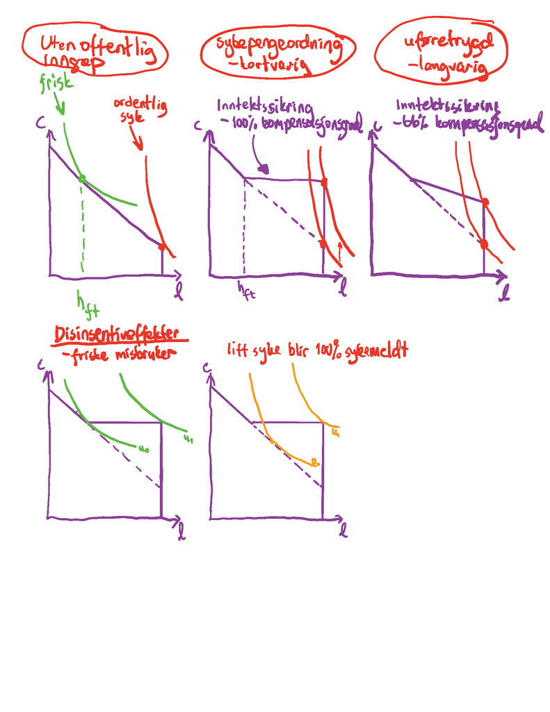

## Uten offentlig inngrep

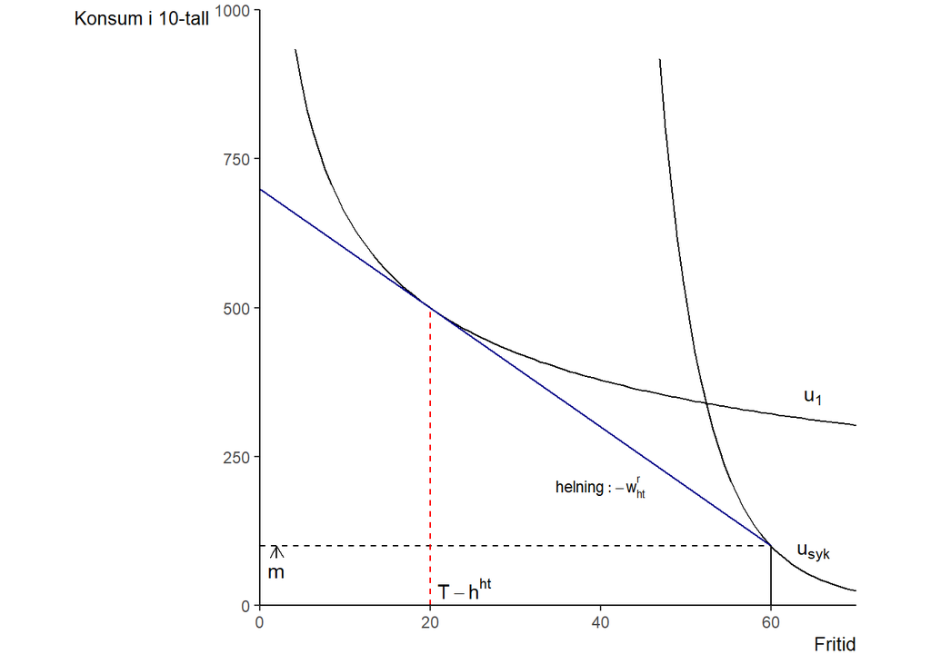

```r
# Last inn de nødvendige pakkene
library(ggplot2)
library(grid)  # For ekstra funksjoner som 'arrow'
# Oppretter en sekvens og lagre den i l_1
l_1 <- seq(0, 60, by = .01)  # l_1 representerer fritid, går fra 0 til 60

# Konverterer sekvensen til en data.frame
df <- data.frame(l_1)  # Dette gjør det enklere å håndtere i ggplot

# Forbereder en ggplot-graf med definerte estetiske verdier og navn på aksene
axes_1 <- ggplot(df, aes(l_1)) +  # Plottet basert på 'l_1' (fritid)
  labs(x="Fritid", y="Konsum i 10-tall") +  # Merker aksene
  theme(
    axis.title = element_text(size = 10),  # Tilpasser størrelsen på aksen titlene
    plot.title = element_text(size = 10),  # Tilpasser størrelsen på plottets tittel
    panel.background = element_blank(),  # Fjern bakgrunnen
    axis.line = element_line(colour = "black"),  # Gjør akselinjene svarte
    axis.title.x = element_text(hjust = 1),  # Justering av x-akse tittelen
    axis.title.y = element_text(angle = 0, vjust = 1, hjust=1)  # Justering av y-akse tittelen
  ) +
  #coord_fixed(ratio = 1) +  # Holder forholdet mellom x- og y-aksene konstant
  scale_x_continuous(limits = c(0, 70), expand = c(0, 0)) +  # Definerer grensene for x-aksen
  scale_y_continuous(limits = c(0, 1000), expand = c(0, 0)) +  # Definerer grensene for y-aksen
  coord_fixed(ratio = (70 - 0) / (1000 - 0))  # Sørger for at akselinjene møtes i (0,0)

# Definerer indifferenskurver (Cobb-Douglas nyttefunksjoner) i optimale punkter i oppgavene a), b) og c)
# vi angir noen indifferenskurver
I_0 <- function(l_1) ((140.11310323534026984156338498747)/(l_1^0.6))^(1/0.4)# maksimalt nyttenivå (som funksjon av c) når Gertrud er LITT SYK (vi setter inn de optimale verdiene av c og l som vi har funnet ved hjelp
# av Lagrange for å finne verdien for U)  og kompensasjonsgraden er 100%
I_2 <- function(l_1) ((199.323531563868829097371190248)/(l_1^0.28571428571428571428571428571429))^(1/0.71428571428571428571428571428571)  # maksimalt nyttenivå (som funksjon av c) når Gertrud er FRISK (vi setter inn de #optimale verdiene av c og l)
I_3 <- function(l_1) ((63.144586748935524613551813968465)/(l_1^0.9))^(1/0.1) # # maksimalt nyttenivå (som funksjon av c) når Gertrud er LITT SYK (vi setter inn de optimale verdiene av c og l som vi har funnet ved hjelp av #Lagrange for å finne verdien for U) og kompensasjonsgraden er 25%

# Definerer budsjettlinjer med og uten sykepenger
wr <- function(l_1) {
  return(700 - 10 * l_1)  # Budsjettlinje uten sykepenger
}
wrsp_0 <- function(l_1) {
  return(500 - 0*10* l_1)  # Budsjettlinje med 100% sykepenger
}

wrsp_1 <- function(l_1) {
  return(650 - 0.75*10* l_1)  # Budsjettlinje med 25% sykepenger
}
# Tegner den optimale tilpasningen uten sykepenger
figur_1 <- axes_1 +  # Basen av plottet
  #    stat_function(df,
  #                  fun=I_0,
  #                  mapping = aes()
  #    )+
  # stat_function(df,
  #              fun=I_1,
  #             mapping = aes()
  #  )+
  stat_function(df,
                fun=I_2,
                mapping = aes()
  )+
     stat_function(df,
                    fun=I_3,
                    mapping = aes()
      )+
  annotate("text",
           x=65,
           y=350,
           label=expression(u[1]))+
  geom_segment(aes(x = 0, y = wr(0), xend = 60, yend = wr(60)), color="darkblue") +  # Tegner budsjettlinje
  annotate("text", x=40,y=200, size = 3,
           label= expression(helning: -w[ht]^{r}))+
  #  geom_segment(aes(x = 20, y = wrsp_0(20), xend = 60, yend = wrsp_0(60)), color="blue") +
  #  geom_segment(aes(x = 20, y = wrsp_1(20), xend = 60, yend = wrsp_1(60)), color="blue") +
  #  annotate("text",x=40,y=430, size = 3,
  #          label= expression(helning: -(w-k*w)))+
  geom_segment(aes(x=60, y=0, xend=60, yend=100))+
  # geom_segment(aes(x=60, y=100, xend=60, yend=500), color="darkgray", linewidth=2)+
  # geom_segment(aes(x=60, y=100, xend=60, yend=200), color="black", linewidth=2)+
  geom_segment(aes(x=0, y=100, xend=60, yend=100), linetype="dashed")+
  annotate("text",x=2,y=60,
           label="m")+
  geom_segment(aes(x=2, y=80, xend=2, yend=100),
               arrow = arrow(length = unit(0.25, "cm")))+
  geom_segment(aes(x=20, y=0, xend=20, yend=500), linetype="dashed", color="red")+
  annotate("text",x=24,y=30,
           label=expression(T-h^{ht}))+
  annotate("text",
           x=65,
           y=90,
           label=expression(u[syk]))
figur_1
```

## Med sykepenger (100 % kompensasjonsgrad)

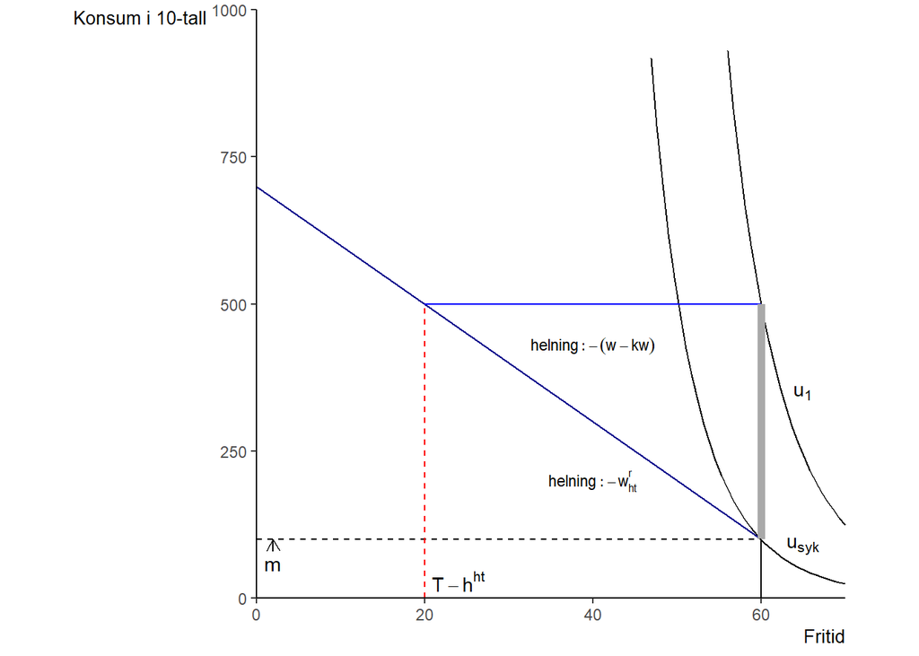

```r
# Last inn de nødvendige pakkene
library(ggplot2)
library(grid)  # For ekstra funksjoner som 'arrow'
# Oppretter en sekvens og lagre den i l_1
l_1 <- seq(0, 60, by = .01)  # l_1 representerer fritid, går fra 0 til 60

# Konverterer sekvensen til en data.frame
df <- data.frame(l_1)  # Dette gjør det enklere å håndtere i ggplot

# Forbereder en ggplot-graf med definerte estetiske verdier og navn på aksene
axes_1 <- ggplot(df, aes(l_1)) +  # Plottet basert på 'l_1' (fritid)
  labs(x="Fritid", y="Konsum i 10-tall") +  # Merker aksene
  theme(
    axis.title = element_text(size = 10),  # Tilpasser størrelsen på aksen titlene
    plot.title = element_text(size = 10),  # Tilpasser størrelsen på plottets tittel
    panel.background = element_blank(),  # Fjern bakgrunnen
    axis.line = element_line(colour = "black"),  # Gjør akselinjene svarte
    axis.title.x = element_text(hjust = 1),  # Justering av x-akse tittelen
    axis.title.y = element_text(angle = 0, vjust = 1, hjust=1)  # Justering av y-akse tittelen
  ) +
  #coord_fixed(ratio = 1) +  # Holder forholdet mellom x- og y-aksene konstant
  scale_x_continuous(limits = c(0, 70), expand = c(0, 0)) +  # Definerer grensene for x-aksen
  scale_y_continuous(limits = c(0, 1000), expand = c(0, 0)) +  # Definerer grensene for y-aksen
  coord_fixed(ratio = (70 - 0) / (1000 - 0))  # Sørger for at akselinjene møtes i (0,0)

# Definerer indifferenskurver (Cobb-Douglas nyttefunksjoner) i optimale punkter i oppgavene a), b) og c)
# vi angir noen indifferenskurver
I_0 <- function(l_1) ((140.11310323534026984156338498747)/(l_1^0.6))^(1/0.4)# maksimalt nyttenivå (som funksjon av c) når Gertrud er LITT SYK (vi setter inn de optimale verdiene av c og l som vi har funnet ved hjelp
# av Lagrange for å finne verdien for U)  og kompensasjonsgraden er 100%
I_2 <- function(l_1) ((74.170827748764376051241635152041)/(l_1^0.9))^(1/0.1)  # maksimalt nyttenivå (som funksjon av c) når Gertrud er FRISK (vi setter inn de #optimale verdiene av c og l)
I_3 <- function(l_1) ((63.144586748935524613551813968465)/(l_1^0.9))^(1/0.1) # # maksimalt nyttenivå (som funksjon av c) når Gertrud er LITT SYK (vi setter inn de optimale verdiene av c og l som vi har funnet ved hjelp av #Lagrange for å finne verdien for U) og kompensasjonsgraden er 25%

# Definerer budsjettlinjer med og uten sykepenger
wr <- function(l_1) {
  return(700 - 10 * l_1)  # Budsjettlinje uten sykepenger
}
wrsp_0 <- function(l_1) {
  return(500 - 0*10* l_1)  # Budsjettlinje med 100% sykepenger
}

wrsp_1 <- function(l_1) {
  return(650 - 0.75*10* l_1)  # Budsjettlinje med 25% sykepenger
}
# Tegner den optimale tilpasningen uten sykepenger
figur_2 <- axes_1 +  # Basen av plottet
  #    stat_function(df,
  #                  fun=I_0,
  #                  mapping = aes()
  #    )+
  # stat_function(df,
  #              fun=I_1,
  #             mapping = aes()
  #  )+
  stat_function(df,
                fun=I_2,
                mapping = aes()
  )+
  stat_function(df,
                fun=I_3,
                mapping = aes()
  )+
  annotate("text",
           x=65,
           y=350,
           label=expression(u[1]))+
  geom_segment(aes(x = 0, y = wr(0), xend = 60, yend = wr(60)), color="darkblue") +  # Tegner budsjettlinje
  annotate("text", x=40,y=200, size = 3,
           label= expression(helning: -w[ht]^{r}))+
    geom_segment(aes(x = 20, y = wrsp_0(20), xend = 60, yend = wrsp_0(60)), color="blue") +
  #  geom_segment(aes(x = 20, y = wrsp_1(20), xend = 60, yend = wrsp_1(60)), color="blue") +
   annotate("text",x=40,y=430, size = 3,
           label= expression(helning: -(w-k*w)))+
  geom_segment(aes(x=60, y=0, xend=60, yend=100))+
   geom_segment(aes(x=60, y=100, xend=60, yend=500), color="darkgray", linewidth=2)+
  # geom_segment(aes(x=60, y=100, xend=60, yend=200), color="black", linewidth=2)+
  geom_segment(aes(x=0, y=100, xend=60, yend=100), linetype="dashed")+
  annotate("text",x=2,y=60,
           label="m")+
  geom_segment(aes(x=2, y=80, xend=2, yend=100),
               arrow = arrow(length = unit(0.25, "cm")))+
  geom_segment(aes(x=20, y=0, xend=20, yend=500), linetype="dashed", color="red")+
  annotate("text",x=24,y=30,
           label=expression(T-h^{ht}))+
  annotate("text",
           x=65,
           y=90,
           label=expression(u[syk]))
figur_2
```

## Løsning: lavere kompensasjonsgrad

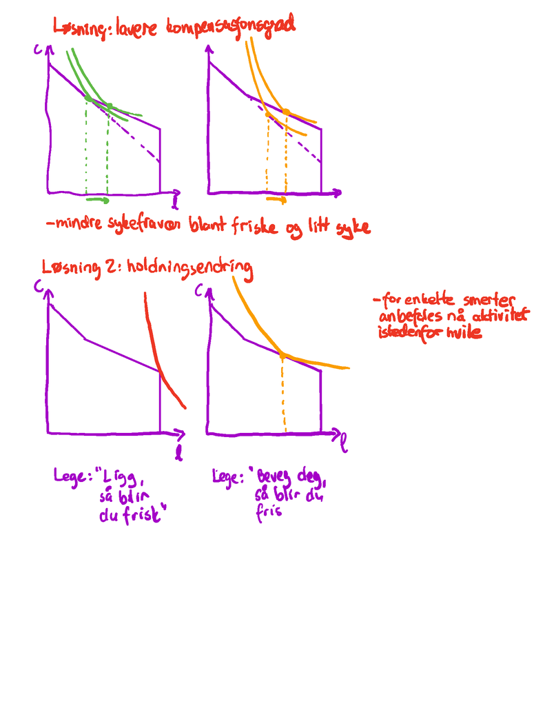

## Sykepenger

### Kompensasjonsgrad

- **Når sykefravær ikke innebærer noe direkte økonomisk tap for arbeidstaker, kan det bidra til høyere sykefravær**
- en stram sykepengeordning, med lav kompensasjonsgrad, kan føre til at personer som ut fra helsetilstand og arbeidsevne ikke burde jobbe, likevel går på jobb
  - For vanlige årsaker til sykefravær som muskel- og skjelettlidelser og lettere psykiske lidelser vil likevel arbeid i mange tilfeller kunne være gunstig
- en fallende kompensasjonsgrad i løpet av en sykepengeperiode vil gi arbeidstaker et økonomisk insentiv til å komme tilbake i arbeid
  - vil også gi arbeidstaker et økonomisk insentiv til å ha gradert sykmelding, siden lønnen er høyere enn sykepengene
  - Med full kompensasjon vil ikke arbeidstaker ha kortsiktige økonomiske gevinster ved gradering
- sykefravær påvirkes av andres fravær, som venner, naboer og kolleger
  - kan forsterke virkningen av økonomiske insentiver og andre faktorer som påvirker sykefraværet

### Sykefraværet og konjunkturer

- I den økonomisk litteraturen fokuseres det på tre forhold for å forklare konjunkturbevegelsene i sykefraværet: disiplineringseffekter, sammensetningseffekter og helseeffekter.

#### Disiplineringseffekt

- Arbeidsgivere vet at sykepenger kan gi arbeidstakere insentiver til å sykmelde seg uten å være (tilstrekkelig) syk
  - arbeidstakeren disiplineres av frykt for at arbeidsgiveren vil oppfatte fraværet som negativt.
- høy ledighet kan øke sannsynligheten for å miste jobben og gjøre det vanskeligere å finne nytt arbeid –> det å bli arbeidsledig vil få større konsekvenser enn når det er lav ledighet
- disiplineringseffekten virker sterkest når arbeidsledigheten er høy
- hindrer friske i å være borte fra jobben
- bidrar også til at syke går på jobb

#### Sammensetningseffekt

- oppstår ved at sysselsettingens sammensetning endres når aktivitetsnivået i økonomien endres
- Ved et høyt aktivitetsnivå vil mer marginale grupper være sysselsatt
  - Disse gruppene antas å ha mer fravær –> sykefraværet vil være høyere (lavere) i perioder med høy (lav) økonomisk aktivitet og høy (lav) sysselsetting

#### Helseeffekt

- hver enkelt arbeidstakers helse svinger med konjunkturene
  - flere kan føle seg utbrente i en høykonjunktur (lav ledighet) på grunn av at et høyt aktivitetsnivå på arbeidsplassen fører til økt fysisk og psykisk belastning

## Uføretrygd

- Kostøl og Mogstad (2014): sterkere økonomiske insentiver fører til at en viss andel av unge uføretrygdede kommer i jobb
- NOU 2021:2 - Kompetanse, aktivitet og inntektssikring — Tiltak for økt sysselsetting
  - Om lag 60 prosent av alle nye uføre har diagnoser innenfor psykiske lidelser eller sykdommer i muskel- og skjelett
  - Forskning og erfaring viser at arbeid i mange tilfeller kan være helsebringende ved denne typen diagnoser
    - en relativt lav andel av uføre i disse gruppene som er i arbeid
  - Det er godt dokumentert at tap av arbeid øker risikoen for å bli uføretrygdet
    - taler for at mange uføre ville kunne jobbe dersom de fikk en egnet jobb
    - Saksbehandleremener at flere uføre kunne kombinert uføretrygd og arbeid dersom forholdene lå bedre til rette for det
  - 23 000 uføre i dagens ordning oppgir selv at de ønsker å arbeide mer
    - I underkant av 20 prosent av de uføre har et arbeidsforhold
- Markussen og Røed (2020): Bidrar medikalisering av ungdom til utstøting fra skole og arbeidsliv?
  - Det har vært en økende tilstrømning til helserelaterte trygdeytelser blant unge mennesker i Norge
    - en betydelig vekst i rapportering av psykiske helseproblemer blant barn og unge
    - indikasjoner på at den lokale tilbøyeligheten til å diagnostisere/utrede/behandle unge for psykiske lidelser
      - har negative effekter på skoleresultater
      - fører til lavere jobbsannsynlighet og høyere risiko for å være trygdemottaker i voksen alder
      - tolker dette som tegn på at sykdomsfokuset i noen grad kan ha blitt for framherskende
      - kan muligens være drevet fram av et underliggende ønske om sikring av rettigheter i velferdsstaten

### Referanser:

- Barmby, T., Sessions, J., & Treble, J. (1994). Absenteeism, efficiency wages and shirking.*The Scandinavian Journal of Economics*, 96(4), 561-566.
- Kostøl, A. R., & Mogstad, M. (2014). How financial incentives induce disability insurance recipients to return to work. *American Economic Review*, 104(2), 624-655.
- Markussen, S., & Røed, K. (2020). Bidrar medikalisering av ungdom til utstøtning fra skole og arbeidsliv?. *Søkelys på arbeidslivet*, 37(4), 219-237.
- NOU. (2021). Kompetanse, aktivitet og inntektssikring–Tiltak for økt sysselsetting.